# Problem Set 3. Due Thurs March 2 5pm

Shanshan Pei

Feb 23, 2017

# Submission

1. Fork this repository to your own account
2. Make changes to the `README.Rmd` file (including the author field above).
3. Knit the file to HTML format and add it to your git repository (`git add`)
4. Submit a pull request with your Rmd and knitted HTML files.

# Overview

You will examine a [time-course of mRNA expression](http://www.ncbi.nlm.nih.gov/pubmed/23175786) of barley powdery mildew fungus in immunocompromised plants (*Arabidopsis*). The fungus Blumeria graminis f. sp. hordei (called *Bgh* from now on)

Counts were generated using the [`maSigPro` software](http://bioinformatics.oxfordjournals.org/content/30/18/2598.full) and deposited in [NCBI GEO](http://www.ncbi.nlm.nih.gov/geo/query/acc.cgi?acc=GSE43163).

Some important identifiers for the data set:

| Name | Description |
| --- | --- |
| `A6` | *Bgh* isolate expressing other AVRA effectors |
| `K1` | *Bgh* isolate expressing the cognate AVRA1 effector for MLA1 |
| `pps` | *Arabidopsis* plants |
| `B12` | *Arabidopsis* plants expressing MLA1-HA |

We will download tables from GEO containing counts of mRNA abundance from both the fungal sample.

# Raw data

First we need load the data.

```r
library(tidyverse)
# bgh data
bgh_url <- 'http://www.ncbi.nlm.nih.gov/geo/download/?acc=GSE43163&format=file&file=GSE43163_CompleteCountTable_Bgh.txt.gz'

# 2 info and blank lines at top, skip them
raw_data <- read_tsv(bgh_url, skip = 2)
# the header for the first column is "NA", set it manually
names(raw_data)[1] <- 'gene.name'

raw_data <- as_data_frame(raw_data)
```

# Problems

## Problem 1

Now that the raw data are loaded, your first task is to tidy the data with `tidyr`. The `cleaned_data` should look something like this:

```
# A tibble: 310,896 × 6
             gene.name plant fungus time.point   rep value
*                <chr> <chr>  <chr>      <chr> <chr> <int>
1             bgh04079   B12     A6       6hpi     1    13
2             bgh01634   B12     A6       6hpi     1    31
3  bghG000012000001001   B12     A6       6hpi     1   121
4  bghG000012000002001   B12     A6       6hpi     1     3
5             bgh00757   B12     A6       6hpi     1   253
6             bgh01273   B12     A6       6hpi     1    45
7             bgh01274   B12     A6       6hpi     1    32
8             bgh01277   B12     A6       6hpi     1     9
9             bgh06140   B12     A6       6hpi     1    47
10            bgh05774   B12     A6       6hpi     1    42
# ... with 310,886 more rows
```

The key steps are to `gather()` the data into key-value pairs and then `separate()` the information from the key column into new columns.

```r
# add tidying code here
raw_data %>%
  gather(key, value, -gene.name) %>%
  separate(key, into = c('plant', 'fungus','time.point','rep'), sep = '_') -> cleaned_data
# report the cleaned_data by just naming it, uncomment the following line:
cleaned_data
```

```
#> # A tibble: 310,896 × 6
#>              gene.name plant fungus time.point   rep value
#> *                <chr> <chr>  <chr>      <chr> <chr> <int>
#> 1             bgh04079   B12     A6       6hpi     1    13
#> 2             bgh01634   B12     A6       6hpi     1    31
#> 3  bghG000012000001001   B12     A6       6hpi     1   121
#> 4  bghG000012000002001   B12     A6       6hpi     1     3
#> 5             bgh00757   B12     A6       6hpi     1   253
#> 6             bgh01273   B12     A6       6hpi     1    45
#> 7             bgh01274   B12     A6       6hpi     1    32
#> 8             bgh01277   B12     A6       6hpi     1     9
#> 9             bgh06140   B12     A6       6hpi     1    47
#> 10            bgh05774   B12     A6       6hpi     1    42
#> # ... with 310,886 more rows
```

## Problem 2

You need to translate what you learned on the command line into the R world.

Which plant has the highest expression of any gene in the 6hpi time point?

```bash
raw_data | awk '$4 == "6hpi"' | sort -k6nr | head -n 1 | cut -f2
```

```r
cleaned_data %>%
  filter(time.point == "6hpi") %>%
  filter(value == max(value)) %>%
  select(plant)
```

```
#> # A tibble: 1 × 1
#>   plant
#>   <chr>
#> 1   pps
```

Which plant / fungus pair has the highest expression in the 18hpi time point?

```bash
raw_data | awk '$4 == "18hpi"' | sort -k6nr | head -n 1 | cut -f2,3
```

```r
cleaned_data %>%
  filter(time.point == "18hpi") %>%
  filter(value == max(value)) %>%
  select(plant,fungus)
```

```
#> # A tibble: 1 × 2
#>   plant fungus
#>   <chr>  <chr>
#> 1   pps     A6
```

## Problem 3

Identify the top 3 most consistently differentially expressed genes between the earliest and latest time points for each combination of `plant` and `fungus` strains.

- “Differential expression”" is the difference between `value` (i.e., gene expression level) between time points.
- “Consistency” is the smallest variance in `value` between replicates.

### Strategy

1. Create a new table from the cleaned data by moving each `hpi` value to a new column name, with counts for each in the column (hint: use a `tidyr` verb). It is helpful to reformat the `hpi` values by converting from e.g. `6hpi` to `hpi.6`. You can use `mutate` to do this, i.e.:

```r
library(stringr)
# replace the 6hpi format with the hpi.6 format and generate a new column containing just time value.
cleaned_data %>%
  mutate(time.point = str_replace(time.point, 'hpi', ''), time.point = str_c('hpi.', time.point)) -> cleaned_data_1
# generate new columns that contain expression values for each different time point
cleaned_data_1 %>%
  spread(time.point, value) ->cleaned_data_2
```

2. Create a new column containing the expression difference between the relevant time points.

```r
cleaned_data_2 %>% mutate(expr.diff = hpi.24 - hpi.6) -> expr_data
```

3. Calculate summary statistics (mean and variance) of the expression differences by grouping (hint) the `gene.name`, `plant`, and `virus` columns.

```r
expr_data %>%
  group_by(plant, fungus, gene.name) %>%
  summarise(expr.diff.mean = mean(expr.diff), expr.diff.var = var(expr.diff)) -> expr_summary_stats
```

4. Sort by these statistics and use the `dplyr` verb `slice` to pull the ones you want (i.e., the top 3). Note you will have to remove `gene.name` from the grouping so that sorting works.

```r
expr_summary_stats %>%
  ungroup()%>%
  arrange(plant, fungus, desc(abs(expr.diff.mean)), expr.diff.var) %>%
  group_by(plant, fungus) %>%
  slice(1:3) -> top_genes

top_genes
```

```
#> Source: local data frame [12 x 5]
#> Groups: plant, fungus [4]
#>
#>    plant fungus gene.name expr.diff.mean expr.diff.var
#>    <chr>  <chr>     <chr>          <dbl>         <dbl>
#> 1    B12     A6  bgh01942      -4988.333     726785.33
#> 2    B12     A6  bgh00377      -2539.667     236402.33
#> 3    B12     A6  bgh05405      -2310.667     367852.33
#> 4    B12     K1  bgh01942      -5202.333    2197082.33
#> 5    B12     K1  bgh05405      -3309.333    2173654.33
#> 6    B12     K1  bgh00377      -2902.000     836091.00
#> 7    pps     A6  bgh01942      -5105.000    2448477.00
#> 8    pps     A6  bgh00377      -2801.667     678297.33
#> 9    pps     A6  bgh05405      -2706.000     759601.00
#> 10   pps     K1  bgh01942      -2149.333      20658.33
#> 11   pps     K1  bgh00377      -1106.000      16624.00
#> 12   pps     K1  bgh02634       1092.667     422292.33
```

## Problem 4

Now examine the above final data frame above and write a few sentences putting inline code in least 3 places. For example, There are 32 rows of data in `mtcars`.

The final data frame `top_genes` has 12 rows and 5 columns of data and contains following unique genes: bgh01942 | bgh00377 | bgh05405 | bgh02634.

## Problem 5

Plot the expression (`value`) by time (`hpi`) for the above genes. Format the plot as follows:

1. Plot each point.
2. Connect the points with a smooth line
3. Create a facet for each `plant` / `bgh` pair
4. Assign a different color to each gene
5. Assign a different shape to each replicate
6. Add a descriptive title to the plot
7. Use the “black & white” theme

Extra credit: add error bars to the plot (use `geom_errorbar`).

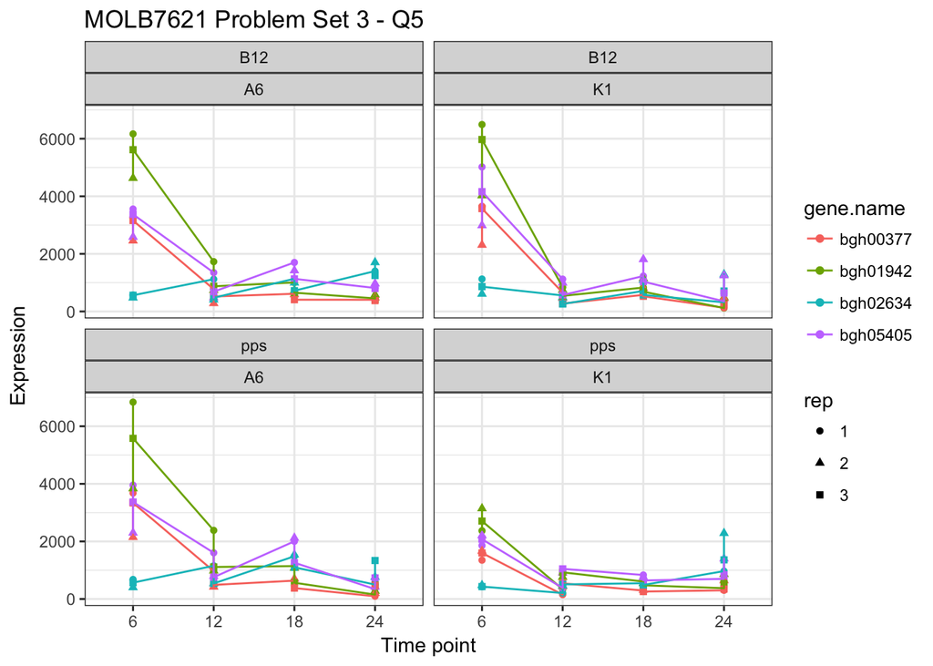

```r
library(ggplot2)
# generate a vector containing unique gene names
top_genes %>% ungroup()%>%select(gene.name) %>% distinct() %>% as_vector() -> unique_gene_list

# filter data
cleaned_data_1 %>%
  filter(gene.name %in% unique_gene_list) %>%
  mutate(time.point = str_replace(time.point, 'hpi.', '')) -> filtered_data

# generate graph
ggplot(filtered_data, aes(x = factor(time.point, levels = c("6","12","18","24")), color= gene.name, shape = rep, y=value, group = gene.name)) + geom_point() + geom_line() + facet_wrap(plant ~fungus) + ggtitle('MOLB7621 Problem Set 3 - Q5') + xlab('Time point') + ylab('Expression') + theme_bw()
```

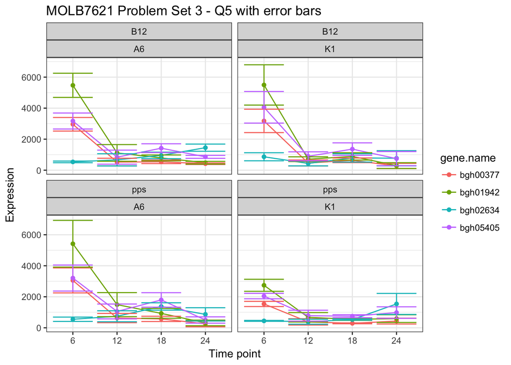

```r
# generate a new graph with error bars

cleaned_data_1 %>% filter(gene.name %in% unique_gene_list) %>% mutate(time.point = str_replace(time.point, 'hpi.', '')) %>% group_by(plant, fungus, gene.name, time.point) %>% summarise(mean=mean(value), sd=sd(value)) -> data_stat

ggplot(data_stat, aes(x = factor(time.point, levels = c("6","12","18","24")), color= gene.name, y=mean, group=gene.name)) + geom_point() + geom_line() + facet_wrap(plant ~fungus) + ggtitle('MOLB7621 Problem Set 3 - Q5 with error bars') + xlab('Time point') + ylab('Expression') + theme_bw() + geom_errorbar(aes(ymin = mean-sd, ymax = mean+sd))
```